# WeightLiftingStudy

armistead

October 29, 2017

## Weightlifting Data Analysis

### Introduction

Research abounds about whether people exercise or not. However, rare is the study about how well people exercise. Thankfully one study from Germany did such research.

In this study, participants were asked to perform one set of 10 repetitions of the Unilateral Dumbbell Biceps Curl in five different fashions: Class A: Exactly according to the specification Class B: throwing the elbows to the front Class C: lifting the dumbbell only halfway Class D: lowering the dumbbell only halfway Class E: throwing the hips to the front

Class A corresponds to the specified execution of the exercise, while the other 4 classes correspond to common mistakes.

Participants were supervised by an experienced weight lifter to make sure the execution complied to the manner they were supposed to simulate. The exercises were performed by six male participants aged between 20-28 years, with little weight lifting experience. We made sure that all participants could easily simulate the mistakes in a safe and controlled manner by using a relatively light dumbbell (1.25kg).

Our task is to perform some exploratory analysis and build a machine learning model to predict how well any given exercise will be performed.

### Getting Started

First let’s load the packages that we plan to use. Tidyverse will allow us some convenient data munging tools. Corrplot will help with Exploratory Data Analysis, and Caret and RandomForest assist with modeling.

```r
library(tidyverse)
```

```r
library(corrplot)
library(caret)
library(randomForest)
```

Then we have to load the data. After a cursory look at the headers available, we’ll take a subset of the columns with only the most meaningful variables and factors.

```r
rawtraining <- read.csv("pml-training.csv", header=TRUE)
rawtesting <- read.csv("pml-testing.csv", header=TRUE, stringsAsFactors = FALSE)
head(rawtraining)
```

[output not shown]

[output cut: 265 more lines]

```r
trainingsubset <- rawtraining %>% select(classe, user_name, num_window,
               roll_belt,pitch_belt,yaw_belt,
               gyros_belt_x,gyros_belt_y,gyros_belt_z,
               accel_belt_x,accel_belt_y,accel_belt_z,
               magnet_belt_x,magnet_belt_y,magnet_belt_z,
               roll_arm,pitch_arm,yaw_arm,
               gyros_arm_x,gyros_arm_y,gyros_arm_z,
               accel_arm_x,accel_arm_y,accel_arm_z,
               magnet_arm_x,magnet_arm_y,magnet_arm_z,
               gyros_dumbbell_x,gyros_dumbbell_y,gyros_dumbbell_z,
               accel_dumbbell_x,accel_dumbbell_y,accel_dumbbell_z,
               magnet_dumbbell_x,magnet_dumbbell_y,magnet_dumbbell_z,
               roll_forearm,pitch_forearm,yaw_forearm,
               gyros_forearm_x,gyros_forearm_y,gyros_forearm_z,
               accel_forearm_x,accel_forearm_y,accel_forearm_z,
               magnet_forearm_x,magnet_forearm_y,magnet_forearm_z)

testingsubset <- rawtesting %>% select(user_name, num_window,
               roll_belt,pitch_belt,yaw_belt,
               gyros_belt_x,gyros_belt_y,gyros_belt_z,
               accel_belt_x,accel_belt_y,accel_belt_z,
               magnet_belt_x,magnet_belt_y,magnet_belt_z,
               roll_arm,pitch_arm,yaw_arm,
               gyros_arm_x,gyros_arm_y,gyros_arm_z,
               accel_arm_x,accel_arm_y,accel_arm_z,
               magnet_arm_x,magnet_arm_y,magnet_arm_z,
               gyros_dumbbell_x,gyros_dumbbell_y,gyros_dumbbell_z,
               accel_dumbbell_x,accel_dumbbell_y,accel_dumbbell_z,
               magnet_dumbbell_x,magnet_dumbbell_y,magnet_dumbbell_z,
               roll_forearm,pitch_forearm,yaw_forearm,
               gyros_forearm_x,gyros_forearm_y,gyros_forearm_z,
               accel_forearm_x,accel_forearm_y,accel_forearm_z,
               magnet_forearm_x,magnet_forearm_y,magnet_forearm_z)
```

### Handling NAs

In this section, we’ll clean things up a bit by creating a logical function for if a value is NA. Then we use the simple map function to remove NAs. We convert the data set to a tibble to prevent any formatting issues downstream.

```r
NAasy <- function(x, y){
  x[is.na(x)] <- y
  x # to return vector after replacement
}

trainingdata <- map(trainingsubset, NAasy, 0)
trainingdata <- as.tibble(trainingdata)

testingdata <- map(testingsubset, NAasy, 0)
testingdata <- as.tibble(testingdata)
```

### Exploration

Since the data is provided to us pre-partitioned between training and test sets, we are ready for a little exploratory data analysis.

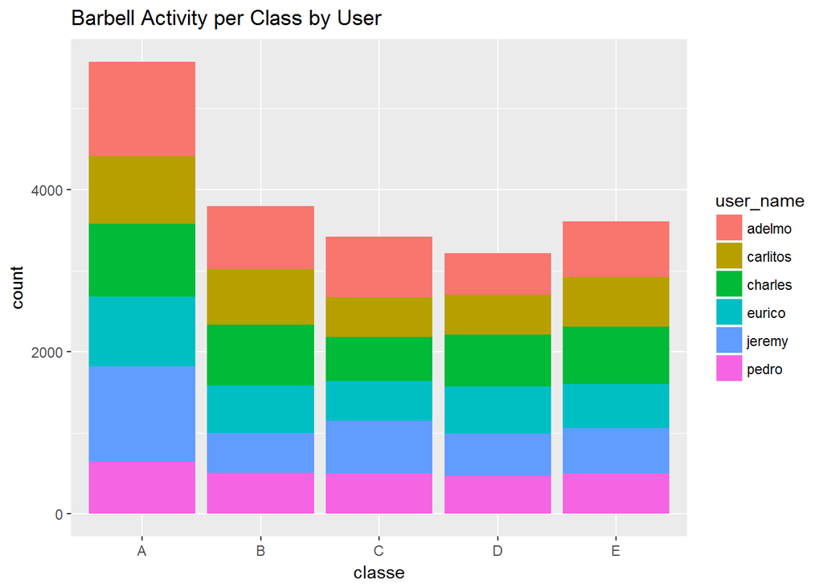

```r
ggplot(trainingdata) +
        geom_bar(mapping = aes(x = classe, fill = user_name)) +
        labs(title=paste("Barbell Activity per Class by User"))
```

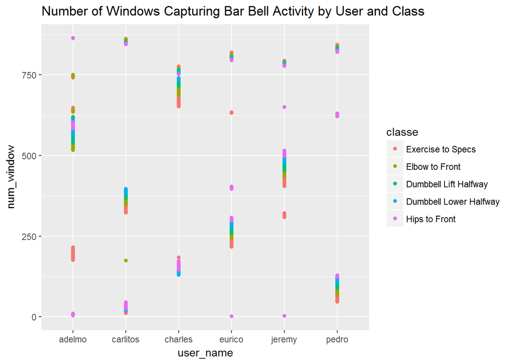

```r
levels(trainingdata$classe) <- c("Exercise to Specs","Elbow to Front","Dumbbell Lift Halfway","Dumbbell Lower Halfway","Hips to Front")

ggplot(trainingdata, aes(x = user_name, y=num_window, color = classe)) +
        geom_point() +
        labs(title=paste("Number of Windows Capturing Bar Bell Activity by User and Class"))
```

Lastly it helps guide research to view correlations among the variables we subset. Roll and Yaw Belt for example seem to have a relationship. Notably Acceleration of Belts Y and Z seem to have a negative correlation. More research could be done as to why.

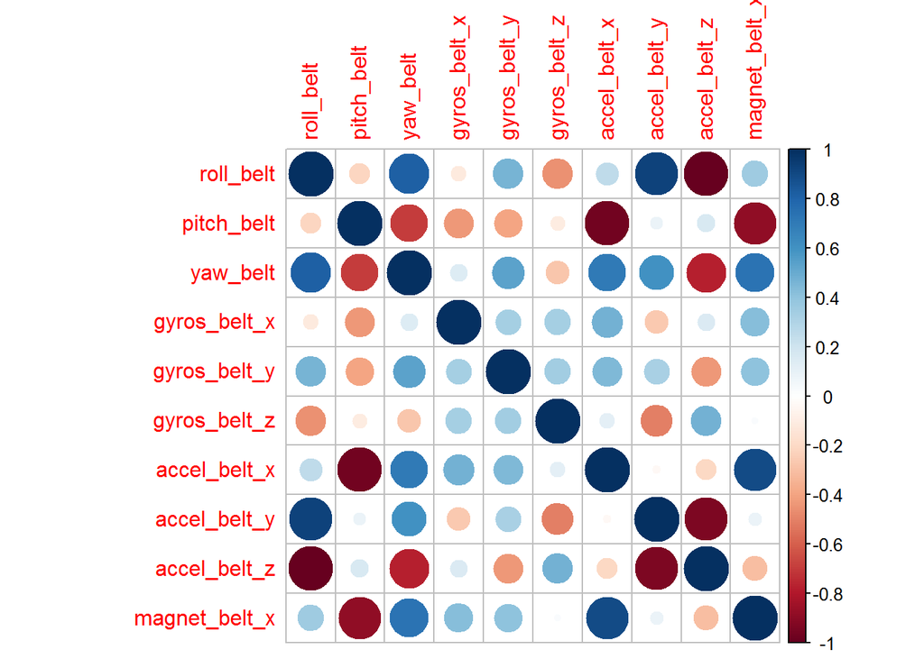

```r
cormax <- cor(trainingdata[, 4:48])
corrplot(cormax[1:10,1:10])
```

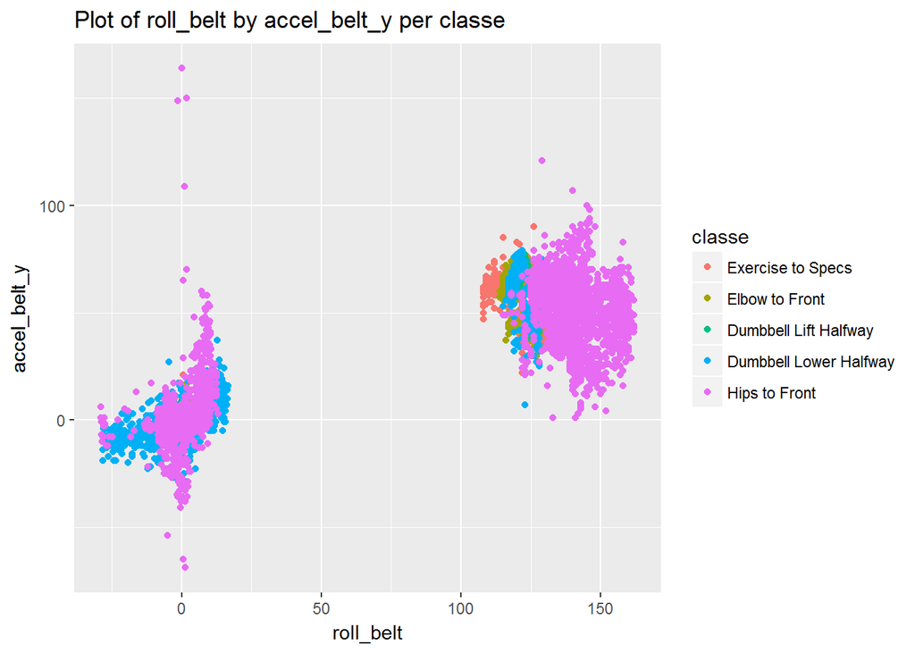

```r
qplot(roll_belt, accel_belt_y, data=trainingdata, color=classe, main='Plot of roll_belt by accel_belt_y per classe')
```

### Modeling

After completing some exploratory data analysis, it’s time to train our model. We’ll use a random forest model to maintain interpretability while allowing for the high correlation classes.

```r
model <- train(classe ~., data=trainingdata, method="rf")
model$finalModel
```

```
##
## Call:
##  randomForest(x = x, y = y, mtry = param$mtry)
##                Type of random forest: classification
##                      Number of trees: 500
## No. of variables tried at each split: 26
##
##         OOB estimate of  error rate: 0.13%
## Confusion matrix:
##                        Exercise to Specs Elbow to Front
## Exercise to Specs                   5578              1
## Elbow to Front                         3           3791
## Dumbbell Lift Halfway                  0              5
## Dumbbell Lower Halfway                 0              0
## Hips to Front                          0              0
##                        Dumbbell Lift Halfway Dumbbell Lower Halfway
## Exercise to Specs                          0                      0
## Elbow to Front                             2                      1
## Dumbbell Lift Halfway                   3416                      1
## Dumbbell Lower Halfway                     9                   3206
## Hips to Front                              0                      2
##                        Hips to Front  class.error
## Exercise to Specs                  1 0.0003584229
## Elbow to Front                     0 0.0015801949
## Dumbbell Lift Halfway              0 0.0017533606
## Dumbbell Lower Halfway             1 0.0031094527
## Hips to Front                   3605 0.0005544774
```

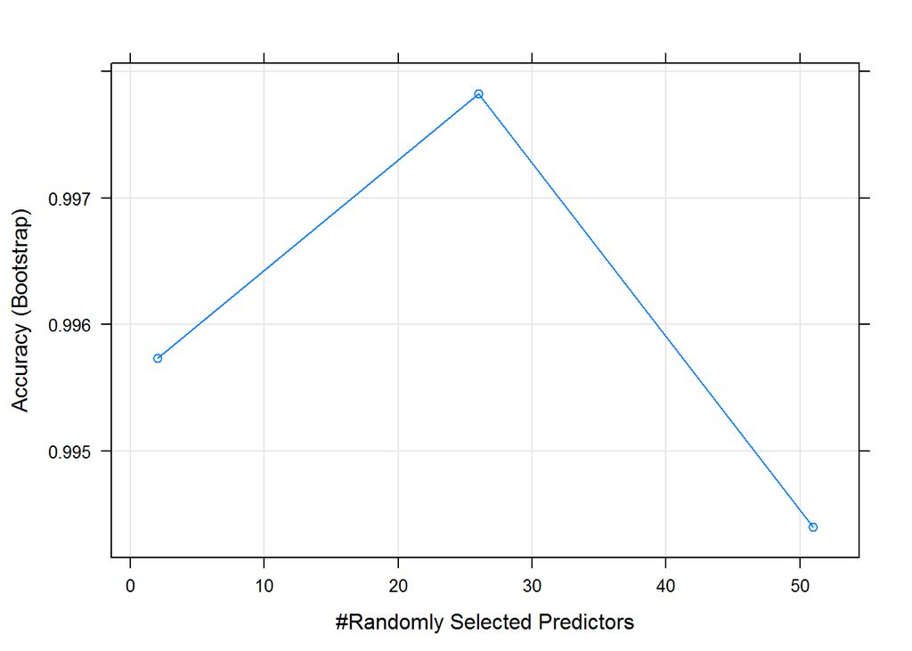

```r
plot(model)
```

### Testing

Finally we must run our test data through the model. Here is where we finally determine how well an individual performs an exercise giving a sample of barbell lifts.

```r
testingpred <- predict(model, newdata = testingdata)

testingpred
```

```
##  [1] Elbow to Front         Exercise to Specs      Elbow to Front
##  [4] Exercise to Specs      Exercise to Specs      Hips to Front
##  [7] Dumbbell Lower Halfway Elbow to Front         Exercise to Specs
## [10] Exercise to Specs      Elbow to Front         Dumbbell Lift Halfway
## [13] Elbow to Front         Exercise to Specs      Hips to Front
## [16] Hips to Front          Exercise to Specs      Elbow to Front
## [19] Elbow to Front         Elbow to Front
## 5 Levels: Exercise to Specs Elbow to Front ... Hips to Front
```

```
References
Velloso, E.; Bulling, A.; Gellersen, H.; Ugulino, W.; Fuks, H. Qualitative Activity Recognition of Weight Lifting Exercises. Proceedings of 4th International Conference in Cooperation with SIGCHI (Augmented Human '13) . Stuttgart, Germany: ACM SIGCHI, 2013.
```